# Assignment 1 ETC1010 - 31444059

Victoria Crime Analysis Report

Jason Abi Chebli

Friday, August 18 2023

# ℹ️️ Informations

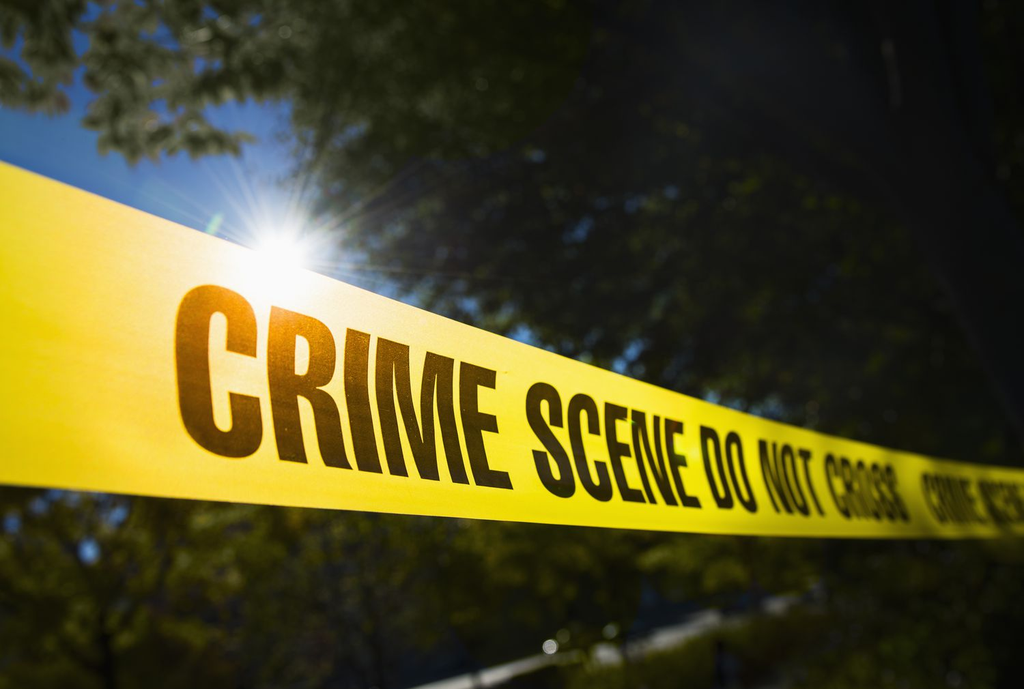

This is a real dataset collected by Australian Bureau of Statistics (https://www.crimestatistics.vic.gov.au/). You work as the data analyst at the crime department and are responsible to write a report with some key statistics to describe the data. All the questions in this assignment will help you to collect all relevant information for your report.

## 🏣 Marking + Grades + Due date

- This **individual** assignment is worth **10%** of your total grade, and will be marked out of a total of 35 marks for undergraduate students and a total of 45 marks for postgraduate students.
- This assignment is due at **11.55pm (Melbourne Time) on Sunday, 20th August 2023**.
- For this assignment, you will need to upload the rendered **HTML** file into Moodle. Please make sure you add your name in the YAML part of this Rmd file. The HTML file will be used as your final answers to the assignment. (Remember that you need to submit the html only. Therefore all the codes need to be visible.)

## 🆘 How to find help from R functions?

Remember, you can look up the help file for functions by typing: `?function_name`. For example, `?mean`. Feel free to google questions you have about constructing different kinds of plots, and post on the “Discussion Forum” with any general questions you have about the assignment (Please DO NOT post any of your answers in the forum).

## 🔩 Instructions

Read https://www.abs.gov.au/methodologies/recorded-crime-victims-methodology/2022 to find out more about the dataset.  
- You are not allowed to type the answer manually in paragraph if the answer can be obtained using R, use inline R code instead.  
- When a plot is required, it has to be labelled properly with an appropriate title, labels and legends (if necessary). Treat this as a proper report.  
- All questions need a proper explanation. You cannot show a table or graph without any explanation in a report. 🤪

If you want to look at how the assignment looks like in progress with some of the R codes remaining invalid in the R code chunks, remember that you can set the R chunk options to `eval = FALSE` like so:

````markdown
```{r this-chunk-will-not-run, eval = FALSE}
ggplot()
```
````

**If you use `eval = FALSE` or `cache = TRUE`, please remember to ensure that you have set to `eval = TRUE` when you submit the assignment, to ensure all your R codes run as expected.**

# 🗄️Report

## Part A: All students are required to complete this section. Please use embedded R code (inline R code) when necessary; hard coding is not permitted.

Load all the R packages that you will be using in this report here.

```r
# Load the required packages
library(tidyverse)
library(kableExtra)
library(readr)
```

### Question 1: Data reading and preparation. Read in the provided dataset. Name the dataset `crime`. [1m]

```r
crime <- read_csv("data/offences.csv") # Read in the data
```

### Question 2: How many observations and variables does this data set contain? Provide a concise description of the dataset. [4m] **Hints**: Utilise your Google-fu to learn more about this dataset’s data collection!

```r
num_observations <- nrow(crime) # Determine the number of observations as observations in tidy data are in rows
num_variables <- ncol(crime) # Determine the number of variables as variables in tidy data are in columns

# Determine the number of different ways to classify a type of crime
num_div <- length(unique(crime$`Offence Division`))
num_sub_div <- length(unique(crime$`Offence Subdivision`))
num_sub_group <- length(unique(crime$`Offence Subgroup`))

# Determine the maximum and minimum year of the data collected
max_year <- max(crime$Year)
min_year <- min(crime$Year)
```

The crime dataset provides a detailed outline of the number of different types of crimes committed in different suburbs/towns in Victoria over the 2014 to 2023 time period. It goes deep in trying to classify the type of crime committed, breaking it down from division, into subdivision and subgroup. There are 6 different offence divisions, 25 different offence subdivisions and 106 different subgroups. It also contains information such as post code, local government area, the year the crimes were committed and how many there were.

The total number of observations in the crime dataset is: 359132.

The total number of variables in the crime dataset is: 9.

**Screenshot of Inline Code:**

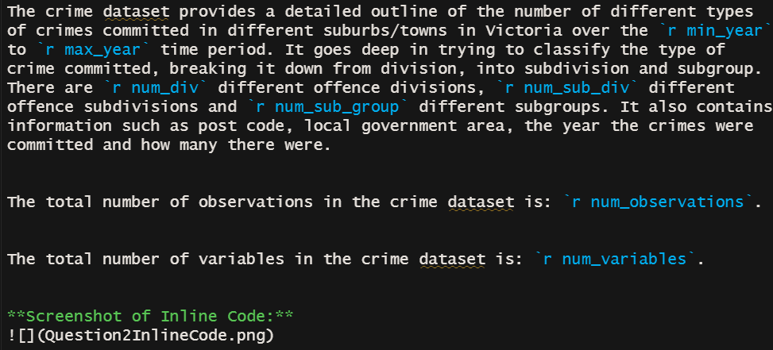

### Question 3: List the dataset’s variables. [1m]

```r
variable_names <- names(crime) # Extract the column (variable) names
```

The variables in the crime dataset are: Year, Year ending, Local Government Area, Postcode, Suburb/Town Name, Offence Division, Offence Subdivision, Offence Subgroup, Offence Count.

**Screenshot of Inline Code:**

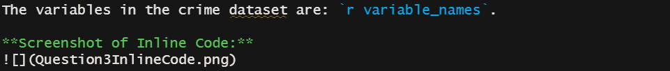

### Question 4: Examine the dataset more closely in order to comprehend it better. Determine whether the data types are formatted correctly. Explain which variable’s data type does not match your expectations if there is any? [2m]

The datatypes for the different variables are determined below.

```r
str(crime) #Look at the datatype of the different variables
```

```
## spc_tbl_ [359,132 × 9] (S3: spec_tbl_df/tbl_df/tbl/data.frame)
##  $ Year                 : num [1:359132] 2023 2023 2023 2023 2023 ...
##  $ Year ending          : chr [1:359132] "March" "March" "March" "March" ...
##  $ Local Government Area: chr [1:359132] "Alpine" "Alpine" "Alpine" "Alpine" ...
##  $ Postcode             : num [1:359132] 3691 3691 3691 3691 3691 ...
##  $ Suburb/Town Name     : chr [1:359132] "Dederang" "Dederang" "Dederang" "Dederang" ...
##  $ Offence Division     : chr [1:359132] "A Crimes against the person" "A Crimes against the person" "B Property and deception offences" "B Property and deception offences" ...
##  $ Offence Subdivision  : chr [1:359132] "A20 Assault and related offences" "Other crimes against the person" "B40 Theft" "B40 Theft" ...
##  $ Offence Subgroup     : chr [1:359132] "A212 Non-FV Serious assault" "Other crimes against the person" "B42 Steal from a motor vehicle" "B49 Other theft" ...
##  $ Offence Count        : num [1:359132] 1 1 2 1 1 1 1 1 1 1 ...
##  - attr(*, "spec")=
##   .. cols(
##   ..   Year = col_double(),
##   ..   `Year ending` = col_character(),
##   ..   `Local Government Area` = col_character(),
##   ..   Postcode = col_double(),
##   ..   `Suburb/Town Name` = col_character(),
##   ..   `Offence Division` = col_character(),
##   ..   `Offence Subdivision` = col_character(),
##   ..   `Offence Subgroup` = col_character(),
##   ..   `Offence Count` = col_double()
##   .. )
##  - attr(*, "problems")=<externalptr>
```

All of the data types are formatted correctly and align with the expected formatting. For instance, `Year endings`, `Local Government Area`, `Suburb/Town Names`, `Offence Division`, `Offence Subdivision` and `Offence Subgroup` all consist of words and are, therefore, categorised as ‘characters’.

However, it’s worth noting that the data type for `Year ending` could potentially be better suited as ‘integer’ rather than ‘character’. This change would involve converting the month names into their respective numbers, such as changing “March” to 3. Furthermore, it’s interesting to observe that the variable `Year ending` contains only one observation - March. Consequently, it’s possible to consider this entire column as redundant.

In relation to the remaining variables - `Year`, `Postcode`, `Offence Count`, they are classified as ‘numeric’ which is appropriate. Additionally, even though they are ‘numeric’, they are currently labeled as ‘doubles’. A more appropriate classification might be to categorise them as ‘integers’, given that `Year`, `Postcode` and `Offence Count` inherently consist of whole numbers and not decimals.

### Question 5: How many Local Government Areas (LGA) are reported in this dataset? [1m]

```r
num_LGA <- crime |>
  select(`Local Government Area`) |> # Only want LGAs
  unique() |> # Need to remove any duplicates of the same LGA
  nrow() # Number of rows equate to number of LGAs
```

In the crime dataset, there are 79 different Local Government Areas (LGAs) reported.

**Screenshot of Inline Code:**

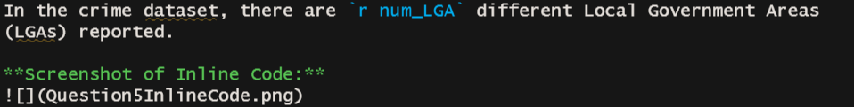

### Question 6: Create a table displaying the crime cases in each LGA. The frequency should be listed in descending order. Which local government areas have the greatest crime risk? Just display the top ten LGAs and their associated crime cases. [4m]

The top 10 LGAs and their associated crime rates can be seen in Table 1.

```r
# Determine the amount of crime each suburb had reported over time
LGA_crimes <- crime |>
  select(`Local Government Area`, `Offence Count`) |>
  filter(!is.na(`Offence Count`)) |> # Removes any offence counts that are NA
  pivot_wider(names_from = `Local Government Area`,
              values_from = `Offence Count`,
              values_fn = sum) |> # This operation was done to be able to sum up the offence counts in the different LGAs
  pivot_longer(everything(), names_to = "Local Government Area", values_to = "Crime") |> # This was done so that the table could be presented in the format style it is
  arrange(desc(Crime))

# Present the data in a nice kable table format
LGA_crimes |>
  head(10) |> # Only shows the top 10
  kable(caption = "Table 1: Top 10 Crime rates between 2014-2023 and associated LGAs.") |>
  kable_styling(latex_options = c("hold_position"))
```

Table 1: Top 10 Crime rates between 2014-2023 and associated LGAs.

| Local Government Area | Crime |
| --- | --- |
| Melbourne | 269498 |
| Greater Geelong | 208755 |
| Casey | 208211 |
| Hume | 198586 |
| Brimbank | 184842 |
| Greater Dandenong | 176525 |
| Wyndham | 154032 |
| Whittlesea | 147234 |
| Darebin | 144214 |
| Frankston | 143576 |

```r
# Determine the highest LGA and the crime count associated with it
high_LGA <- LGA_crimes[1, 1]
high_count <- LGA_crimes[1, 2]

# Determine the second highest LGA and the crime count associated with it
second_high_LGA <- LGA_crimes[2, 1]
second_high_count <- LGA_crimes[2, 2]
```

As can be seen from Table 1, between 2014 to 2023, the LGA that has the highest crime rate is Melbourne, which has an offence count of 269498. This was followed by Greater Geelong which had an offence count of 208755.

**Screenshot of Inline Code:**

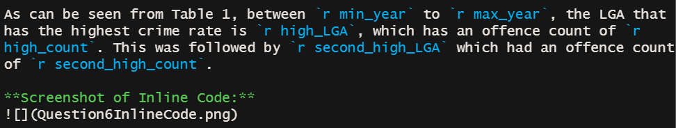

### Question 7: Determine the total number of criminal offences by `Year`. Draw an appropriate plot to show the trend of the reported crime over time. Label the graph properly. Comment on your findings. [6m]

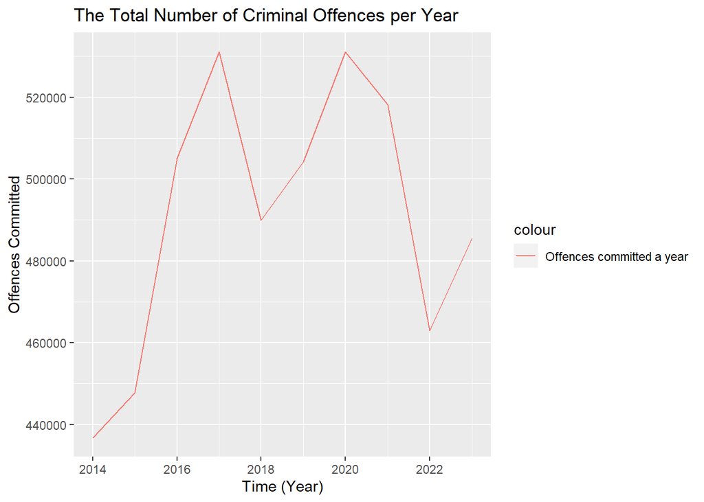

```r
# Determine the number of crimes per year
crime_per_year <- crime |>
  group_by(Year) |>
  summarise(Total_Crime = sum(`Offence Count`, na.rm = TRUE))

# Display the number of crimes per year
crime_per_year |>
  ggplot(aes(x = Year,
             y = Total_Crime,
             col = "Offences committed a year")) +
  geom_line() +
  ylab("Offences Committed") +
  xlab("Time (Year)") +
  ggtitle("The Total Number of Criminal Offences per Year ")
```

### Question 8: Now group the data by `Offence Division` and `Year` to see the overall trend for each form of offence over time in one graph ONLY. Describe your findings. [6m]

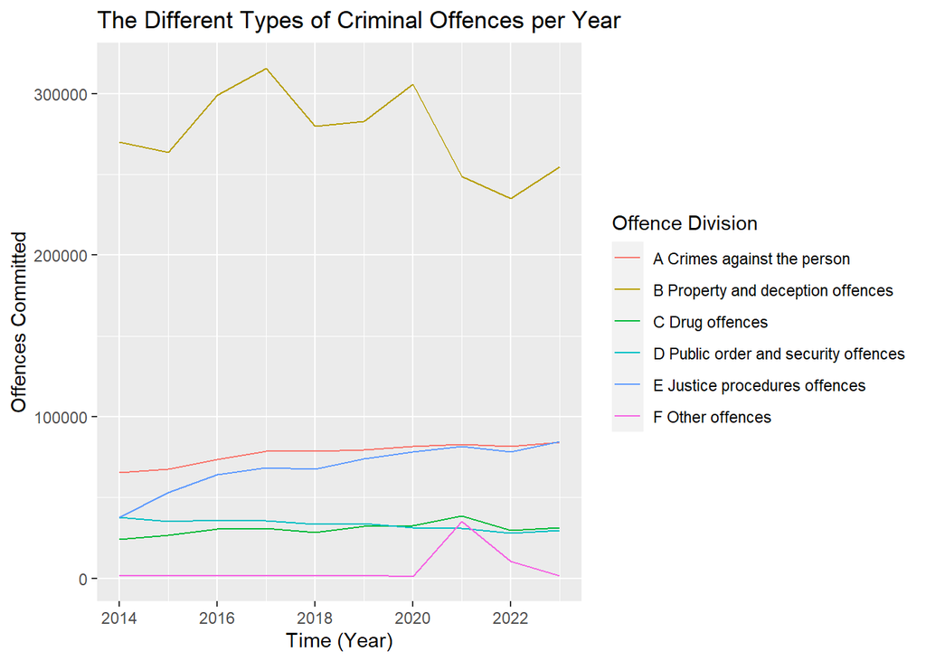

```r
#  Determine the different divisions of crime committed each year
offence_types <- crime |>
  filter(!is.na(`Offence Count`)) |>
  group_by(Year, `Offence Division`) |>
  summarise(Count_Offence_Types = sum(`Offence Count`))

# Display the different divisions of crime committed each year
offence_types |>
  ggplot(aes(x = Year, y = Count_Offence_Types, col = `Offence Division`)) +
  geom_line() +
  ylab("Offences Committed") +
  xlab("Time (Year)") +
  ggtitle("The Different Types of Criminal Offences per Year")
```

As can be seen from this figure, Property and deception offences (Type B) are drastically more common between 2014 and 2023. Additionally, Type B seemed to have the most volatility. As can be seen, it has two peaks (2017 and 2020), however, seems to be on a downwards trend.

Crimes against the person (Type A), Drug offences (Type C) and justice procedure offences (Type E) seem to be slowly growing over time with a slightly upward trend. Out of the three, Type E seems to be growing the fastest.

While the most volatile offence is Type B, we see from the figure that Type C and Type F both have a spike/peak in 2021, potentially related to COVID-19 and the lockdown measures causing more drug and other offences.

### Question 9: Visualise the frequency of each form of offence (using `Offence Division`) for the year 2023 only. Make sure all the labels are readable. [3m]

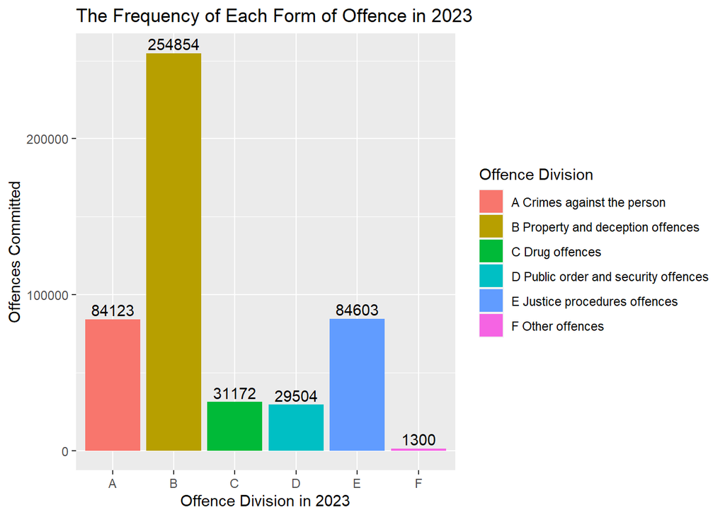

```r
# Determine the frequency of each offence
offences_2023 <- crime |>
  filter(Year == 2023) |>
  group_by(`Offence Division`) |>
  summarise(Total_Offences_2023 = sum(`Offence Count`, na.rm = TRUE)) |>
  mutate(first_letter = substr(`Offence Division`, 1, 1)) # Attaches the letter associated with each type in a separate column - necessary to label the plot x-axis

# Display the frequency of each offence
offences_2023 |>
  ggplot(aes(x = `Offence Division`, y = Total_Offences_2023, fill = `Offence Division`)) +
  geom_bar(stat = "identity") +
  ylab("Offences Committed") +
  xlab("Offence Division in 2023") +
  ggtitle("The Frequency of Each Form of Offence in 2023") +
  geom_text(aes(label = Total_Offences_2023), vjust = -0.3) + # Lets you put the label over each bar
  scale_x_discrete(labels = offences_2023$first_letter) #labels the x-axis with the first letters
```

```r
# Arrange the data in order from highest to lowest offence
arranged_offences <- offences_2023 |>
  arrange(-Total_Offences_2023)

# Determine the highest, second highest and lowest offences and offence counts in 2023
high_offence <- arranged_offences[1, 1]
high_offence_count <- arranged_offences[1, 2]
low_offence <- arranged_offences[nrow(offences_2023), 1]
low_offence_count <- arranged_offences[nrow(offences_2023), 2]
second_highest_offence <- arranged_offences[2, 1]
second_highest_offence_count <- arranged_offences[2, 2]
```

As can be seen, in 2023, the most frequent offence was B Property and deception offences with 254854 offences committed while the least frequent offence was F Other offences with 1300 offences committed. Meanwhile, E Justice procedures offences was the second highest offence, with 84603 offences committed in 2023.

**Screenshot of Inline Code:**

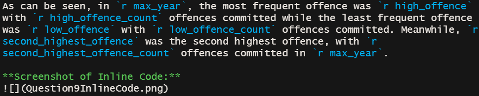

### Question 10: In 2023, based on ‘B Property and deception offences’, which suburb is the safest and which is the most dangerous? If you are interested in choosing the safest suburb in which to reside, justify your findings and list the limitations of your analysis. [7m]

```r
# Determine how many Type B offences each suburb had in 2023, from lowest to highest
offence_B <- crime |>
  filter(Year == 2023)  |>
  filter(substr(`Offence Division`, 1, 1) == "B") |> # Find all of the offence types that start with B
  group_by(`Suburb/Town Name`) |>
  summarise(Total_Offence_B = sum(`Offence Count`, na.rm = TRUE)) |>
  arrange((Total_Offence_B))

# Find the minimum and maximum number of offence B's committed
min_offence_B <- min(offence_B$Total_Offence_B)
max_offence_B <- max(offence_B$Total_Offence_B)

# Find all the safest suburbs
safest_suburbs <- offence_B |>
  filter(Total_Offence_B == min_offence_B) |>
  select(`Suburb/Town Name`)

# Find all the dangerous suburbs
dangerous_suburbs <- offence_B |>
  filter(Total_Offence_B == max_offence_B) |>
  select(`Suburb/Town Name`)

# Determine how many safest and most dangerous suburbs there are
num_safe_suburbs <- nrow(safest_suburbs)
num_dangerous_suburbs <- nrow(dangerous_suburbs)
```

In 2023, there were 387 suburbs classified as the safest - having property and deception offences (Offence Division Type B) occurring only 1 time in 2023. Meanwhile, there was 1 suburb classified as the most dangerous - having property and deception offences (Offence Division Type B) occurring 5592 time in 2023.

As such, the suburb that is the most dangerous is Melbourne. However, due to there being so many different suburbs that have reported the same low number of offences committed, it is not possible to provide one specific suburb that is the safest.

As such, if one truly wanted to determine which suburb to reside in, they should consider more than one type of division of crime as well as potentially considering other factors such as affordability and location.

There are some important limitations in our analysis that should be considered. Firstly, considering just property and deception offences to decide where to live is not extremely a fair analysis. Melbourne has a much larger population compared to many of the ‘safest’ suburbs. As such, while there may be more offences, when considering it per population, it may not score so badly, compared to many more regional towns. Secondly, it is important to think of external factors. Given that Melbourne has more people, more officer enforcement may occur, resulting in a higher rate. Meanwhile, suburbs will less enforcement due to the smaller population may have higher than reported rates as they simply did not have the resources to catch them. Finally, it would make sense that more affluent places have higher chances of property and deception offences as these places have the more expensive properties. Therefore, a better analysis to determine which place is the safest would be to consider a range of types of offences, such as property and deception offences, drug offences, crimes against the person offences and more, to better understand how truly ‘safe’ a place is as some crimes may be more physically dangerous.

**Screenshot of Inline Code:**

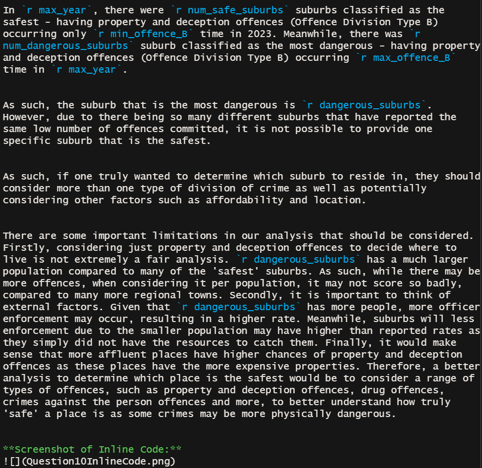

## Part B: **Postgraduate student only** (You are only required to answer this part if you enrolled in ETC5510)

#### Write a report elucidating the conclusions derived from the aforementioned enquiries within word limit of 150 words. The report should consist of several sections, namely: Introduction, Data Collection, Analysis, Findings, and Conclusion. [10m]